# Trajectory simulation

```python
%load_ext autoreload
%autoreload 2
```

%load_ext autoreload %autoreload 2

```python
import numpy as np
import scanpy as sc
import time
from pathlib import Path
import torch
import concord as ccd
import warnings
warnings.filterwarnings('ignore')
%matplotlib inline
import matplotlib as mpl

from matplotlib import font_manager, rcParams
custom_rc = {
    'font.family': 'Arial',  # Set the desired font for this plot
}

mpl.rcParams['svg.fonttype'] = 'none'
mpl.rcParams['pdf.fonttype'] = 42
```

import numpy as np import scanpy as sc import time from pathlib import Path import torch import concord as ccd import warnings warnings.filterwarnings('ignore') %matplotlib inline import matplotlib as mpl from matplotlib import font_manager, rcParams custom_rc = { 'font.family': 'Arial', # Set the desired font for this plot } mpl.rcParams['svg.fonttype'] = 'none' mpl.rcParams['pdf.fonttype'] = 42

```python
proj_name = "simulation_trajectory"
save_dir = f"../save/dev_{proj_name}-{time.strftime('%b%d')}/"
save_dir = Path(save_dir)
save_dir.mkdir(parents=True, exist_ok=True)

data_dir = f"../data/{proj_name}/"
data_dir = Path(data_dir)
data_dir.mkdir(parents=True, exist_ok=True)
device = torch.device('cuda:3' if torch.cuda.is_available() else 'cpu')
print(device)
seed = 0
ccd.ul.set_seed(seed)

file_suffix = f"{time.strftime('%b%d-%H%M')}"
file_suffix
```

proj_name = "simulation_trajectory" save_dir = f"../save/dev_{proj_name}-{time.strftime('%b%d')}/" save_dir = Path(save_dir) save_dir.mkdir(parents=True, exist_ok=True) data_dir = f"../data/{proj_name}/" data_dir = Path(data_dir) data_dir.mkdir(parents=True, exist_ok=True) device = torch.device('cuda:3' if torch.cuda.is_available() else 'cpu') print(device) seed = 0 ccd.ul.set_seed(seed) file_suffix = f"{time.strftime('%b%d-%H%M')}" file_suffix

```
cpu
```

```
'Feb16-1614'
```

## Simulation

```python
state_key = 'time'
batch_key = 'batch'
state_type = 'trajectory'
batch_type = 'batch_specific_features'
distribution = 'normal'
leiden_key = 'leiden_no_noise'
```

state_key = 'time' batch_key = 'batch' state_type = 'trajectory' batch_type = 'batch_specific_features' distribution = 'normal' leiden_key = 'leiden_no_noise'

```python
from Concord.utils.simulation import Simulation

# Create an instance of the Simulation class

sim = Simulation(n_cells=1000, n_genes=100, n_batches=2, n_states=3,
                 state_type=state_type,
                 state_distribution = distribution,
                 state_level=10,
                 state_min_level=0,
                 state_dispersion=2.0,
                 program_structure='linear_bidirectional',
                 program_on_time_fraction=0.1,
                 trajectory_program_num=5,
                 trajectory_cell_block_size_ratio=0.6,
                 trajectory_loop_to=None,
                 batch_distribution = distribution,
                 batch_type=batch_type,
                 batch_level=[10,10],
                 batch_dispersion=[2.0, 2.0],
                 non_neg=True, to_int=True,
                 seed=42)

# Generate the simulated data
adata, adata_state = sim.simulate_data()
```

from Concord.utils.simulation import Simulation # Create an instance of the Simulation class sim = Simulation(n_cells=1000, n_genes=100, n_batches=2, n_states=3, state_type=state_type, state_distribution = distribution, state_level=10, state_min_level=0, state_dispersion=2.0, program_structure='linear_bidirectional', program_on_time_fraction=0.1, trajectory_program_num=5, trajectory_cell_block_size_ratio=0.6, trajectory_loop_to=None, batch_distribution = distribution, batch_type=batch_type, batch_level=[10,10], batch_dispersion=[2.0, 2.0], non_neg=True, to_int=True, seed=42) # Generate the simulated data adata, adata_state = sim.simulate_data()

```
Concord.utils.simulation - INFO - Simulating trajectory with 3 states, distribution: normal with mean expression 10 and dispersion 2.0.
Concord.utils.simulation - INFO - Simulating batch-specific features effect on batch_1 by appending a set of batch-specific genes with normal distributed value with level 10 and dispersion 2.0.
Concord.utils.simulation - INFO - Simulating batch-specific features effect on batch_2 by appending a set of batch-specific genes with normal distributed value with level 10 and dispersion 2.0.
```

```python
ccd.pl.heatmap_with_annotations(adata_state, val='no_noise', obs_keys=[state_key], yticklabels=False, cluster_cols=False, cluster_rows=False, value_annot=False, cmap='viridis', title='True state', save_path=save_dir/f'true_state_heatmap_{file_suffix}.png', figsize=(6, 4), dpi=300)
ccd.pl.heatmap_with_annotations(adata_state, val='wt_noise', obs_keys=[state_key], yticklabels=False, cluster_cols=False, cluster_rows=False, value_annot=False, cmap='viridis', title='True state with noise', save_path=save_dir/f'true_state_with_noise_heatmap_{file_suffix}.png', figsize=(6, 4), dpi=300)
ccd.pl.heatmap_with_annotations(adata, val='X', obs_keys=[state_key, batch_key], yticklabels=False, cluster_cols=False, cluster_rows=False, value_annot=False, cmap='viridis', title='Simulated data with batch signal', save_path=save_dir/f'simulated_data_heatmap_{file_suffix}.png', figsize=(6, 4), dpi=300)
```

ccd.pl.heatmap_with_annotations(adata_state, val='no_noise', obs_keys=[state_key], yticklabels=False, cluster_cols=False, cluster_rows=False, value_annot=False, cmap='viridis', title='True state', save_path=save_dir/f'true_state_heatmap_{file_suffix}.png', figsize=(6, 4), dpi=300) ccd.pl.heatmap_with_annotations(adata_state, val='wt_noise', obs_keys=[state_key], yticklabels=False, cluster_cols=False, cluster_rows=False, value_annot=False, cmap='viridis', title='True state with noise', save_path=save_dir/f'true_state_with_noise_heatmap_{file_suffix}.png', figsize=(6, 4), dpi=300) ccd.pl.heatmap_with_annotations(adata, val='X', obs_keys=[state_key, batch_key], yticklabels=False, cluster_cols=False, cluster_rows=False, value_annot=False, cmap='viridis', title='Simulated data with batch signal', save_path=save_dir/f'simulated_data_heatmap_{file_suffix}.png', figsize=(6, 4), dpi=300)

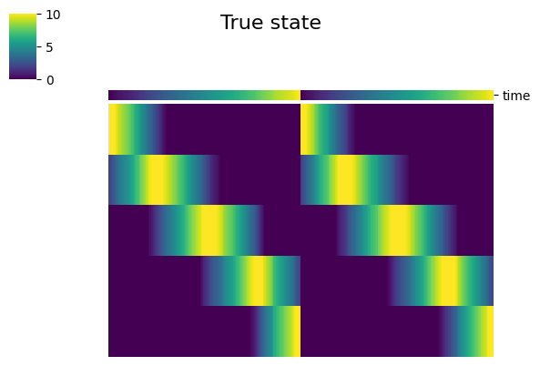

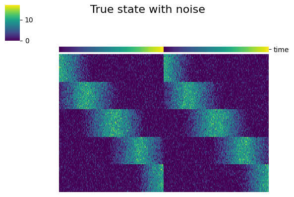

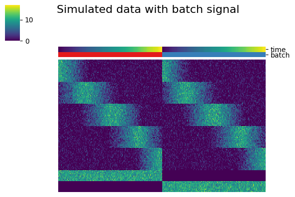

## Visualization

### No batch effect, no noise

```python
ccd.ul.run_pca(adata_state, source_key='no_noise', result_key='PCA_no_noise', n_pc=30, random_state=seed)
ccd.ul.run_umap(adata_state, source_key='PCA_no_noise', result_key='UMAP_no_noise', random_state=seed)
```

ccd.ul.run_pca(adata_state, source_key='no_noise', result_key='PCA_no_noise', n_pc=30, random_state=seed) ccd.ul.run_umap(adata_state, source_key='PCA_no_noise', result_key='UMAP_no_noise', random_state=seed)

```
Concord - INFO - PCA performed on source data with 30 components
Concord - INFO - PCA embedding stored in adata.obsm['PCA_no_noise']
Concord - INFO - UMAP embedding stored in adata.obsm['UMAP_no_noise']
```

```python
sc.pp.neighbors(adata_state, use_rep='PCA_no_noise', n_neighbors=30, random_state=seed)
sc.tl.leiden(adata_state, resolution=1.0, key_added=leiden_key, random_state=seed)
adata.obs[leiden_key] = adata_state.obs[leiden_key]
```

sc.pp.neighbors(adata_state, use_rep='PCA_no_noise', n_neighbors=30, random_state=seed) sc.tl.leiden(adata_state, resolution=1.0, key_added=leiden_key, random_state=seed) adata.obs[leiden_key] = adata_state.obs[leiden_key]

```python
show_basis = 'PCA_no_noise'
show_cols = [state_key, leiden_key, batch_key]

ccd.pl.plot_embedding(
    adata_state, show_basis, show_cols, figsize=(7.5,2.5), dpi=300, ncols=3, font_size=5, point_size=20, legend_loc='on data', rasterized=False,
    save_path=save_dir / f"nobatch_{show_basis}_{file_suffix}.pdf"
)
```

show_basis = 'PCA_no_noise' show_cols = [state_key, leiden_key, batch_key] ccd.pl.plot_embedding( adata_state, show_basis, show_cols, figsize=(7.5,2.5), dpi=300, ncols=3, font_size=5, point_size=20, legend_loc='on data', rasterized=False, save_path=save_dir / f"nobatch_{show_basis}_{file_suffix}.pdf" )

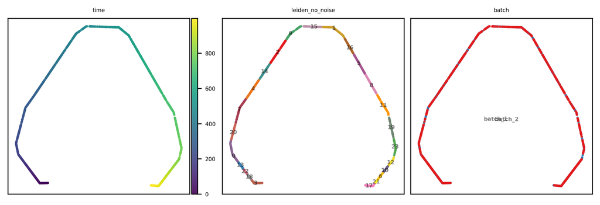

```python
show_basis = 'UMAP_no_noise'
show_cols = [state_key, leiden_key]

ccd.pl.plot_embedding(
    adata_state, show_basis, show_cols, figsize=(8,3), dpi=300, ncols=3, font_size=5, point_size=20, legend_loc='on data',
    save_path=save_dir / f"nobatch_{show_basis}_{file_suffix}.png"
)
```

show_basis = 'UMAP_no_noise' show_cols = [state_key, leiden_key] ccd.pl.plot_embedding( adata_state, show_basis, show_cols, figsize=(8,3), dpi=300, ncols=3, font_size=5, point_size=20, legend_loc='on data', save_path=save_dir / f"nobatch_{show_basis}_{file_suffix}.png" )

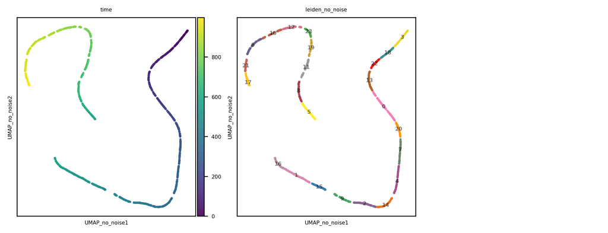

### No batch effect, noise added, PCA and UMAP

```python
adata_state.X = adata_state.layers['wt_noise'].copy()
ccd.ul.run_pca(adata_state, source_key='wt_noise', result_key='PCA_wt_noise', n_pc=30, random_state=seed)
ccd.ul.run_umap(adata_state, source_key='PCA_wt_noise', result_key='UMAP_wt_noise', random_state=seed)
```

adata_state.X = adata_state.layers['wt_noise'].copy() ccd.ul.run_pca(adata_state, source_key='wt_noise', result_key='PCA_wt_noise', n_pc=30, random_state=seed) ccd.ul.run_umap(adata_state, source_key='PCA_wt_noise', result_key='UMAP_wt_noise', random_state=seed)

```
Concord - INFO - PCA performed on source data with 30 components
Concord - INFO - PCA embedding stored in adata.obsm['PCA_wt_noise']
Concord - INFO - UMAP embedding stored in adata.obsm['UMAP_wt_noise']
```

```python
show_basis = 'PCA_wt_noise'
show_cols = [state_key, leiden_key, batch_key]

ccd.pl.plot_embedding(
    adata_state, show_basis, show_cols, figsize=(7.5,2.5), dpi=300, ncols=3, font_size=5, point_size=20, legend_loc='on data', rasterized=False,
    save_path=save_dir / f"nobatch_{show_basis}_{file_suffix}.pdf"
)
```

show_basis = 'PCA_wt_noise' show_cols = [state_key, leiden_key, batch_key] ccd.pl.plot_embedding( adata_state, show_basis, show_cols, figsize=(7.5,2.5), dpi=300, ncols=3, font_size=5, point_size=20, legend_loc='on data', rasterized=False, save_path=save_dir / f"nobatch_{show_basis}_{file_suffix}.pdf" )

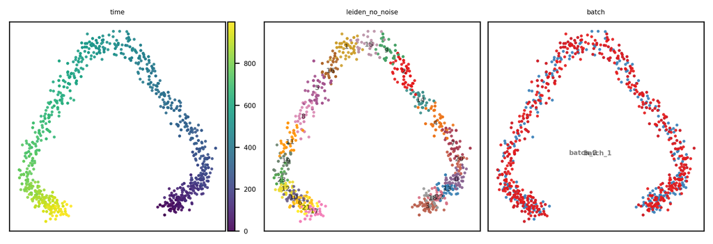

```python
show_basis = 'UMAP_wt_noise'
show_cols = [state_key, leiden_key]

ccd.pl.plot_embedding(
    adata_state, show_basis, show_cols, figsize=(8,3), dpi=300, ncols=3, font_size=5, point_size=20, legend_loc='on data',
    save_path=save_dir / f"nobatch_{show_basis}_{file_suffix}.png"
)
```

show_basis = 'UMAP_wt_noise' show_cols = [state_key, leiden_key] ccd.pl.plot_embedding( adata_state, show_basis, show_cols, figsize=(8,3), dpi=300, ncols=3, font_size=5, point_size=20, legend_loc='on data', save_path=save_dir / f"nobatch_{show_basis}_{file_suffix}.png" )

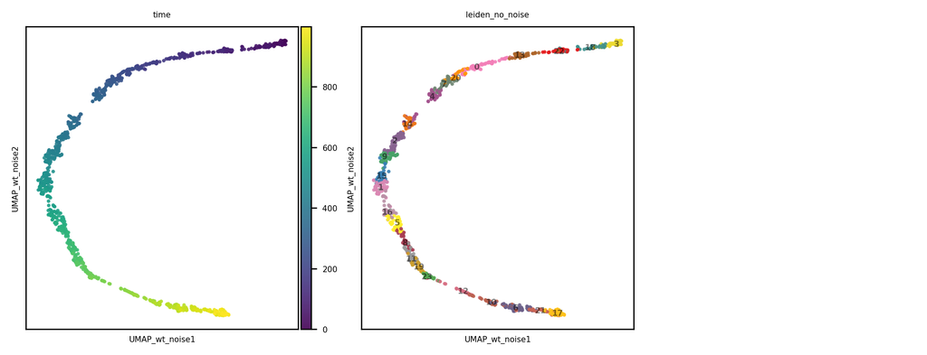

### No batch correction, PCA and UMAP

```python
n_pcs = min(adata.n_obs, adata.n_vars)-1
sc.pp.pca(adata, n_comps=n_pcs)
sc.pp.neighbors(adata, n_neighbors=30, n_pcs=n_pcs)
sc.tl.umap(adata, min_dist=0.5)
adata.obsm["Unintegrated"] = adata.obsm["X_pca"]
```

n_pcs = min(adata.n_obs, adata.n_vars)-1 sc.pp.pca(adata, n_comps=n_pcs) sc.pp.neighbors(adata, n_neighbors=30, n_pcs=n_pcs) sc.tl.umap(adata, min_dist=0.5) adata.obsm["Unintegrated"] = adata.obsm["X_pca"]

```python
show_basis = 'X_pca'
show_cols = [state_key, batch_key, leiden_key]

ccd.pl.plot_embedding(
    adata, show_basis, show_cols, figsize=(8,3), dpi=300, ncols=3, font_size=5, point_size=20, legend_loc='on data',
    save_path=save_dir / f"wtbatch_{show_basis}_{file_suffix}.png"
)
```

show_basis = 'X_pca' show_cols = [state_key, batch_key, leiden_key] ccd.pl.plot_embedding( adata, show_basis, show_cols, figsize=(8,3), dpi=300, ncols=3, font_size=5, point_size=20, legend_loc='on data', save_path=save_dir / f"wtbatch_{show_basis}_{file_suffix}.png" )

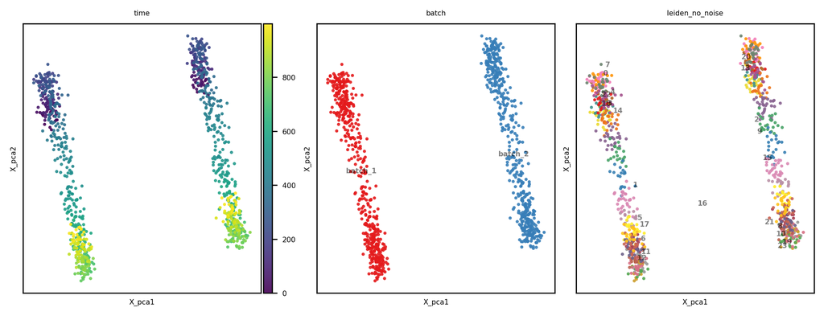

```python
show_basis = 'X_umap'
ccd.pl.plot_embedding(
    adata, show_basis, show_cols, figsize=(8,3), dpi=300, ncols=3, font_size=5, point_size=20, legend_loc='on data',
    save_path=save_dir / f"wtbatch_{show_basis}_{file_suffix}.png"
)
```

show_basis = 'X_umap' ccd.pl.plot_embedding( adata, show_basis, show_cols, figsize=(8,3), dpi=300, ncols=3, font_size=5, point_size=20, legend_loc='on data', save_path=save_dir / f"wtbatch_{show_basis}_{file_suffix}.png" )

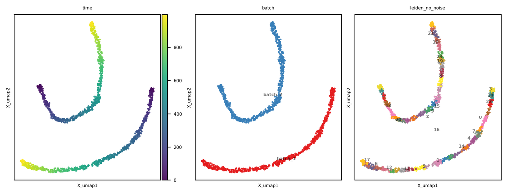

### Concord

```python
cur_ccd = ccd.Concord(adata=adata,
                      input_feature=None,
                      batch_size=64,
                      n_epochs=10,
                      domain_key=batch_key, # key indicating batch
                      seed=seed, # random seed
                      verbose=False, # print training progress
                      device=device, # device to run on
                      save_dir=save_dir # directory to save model checkpoints
                      )

# Encode data, saving the latent embedding in adata.obsm['Concord']
output_key = 'Concord'

cur_ccd.encode_adata(input_layer_key='X', output_key=output_key, preprocess=False)

# Save the latent embedding to a file, so that it can be loaded later
ccd.ul.save_obsm_to_hdf5(cur_ccd.adata, save_dir / f"obsm_{file_suffix}.h5")
```

cur_ccd = ccd.Concord(adata=adata, input_feature=None, batch_size=64, n_epochs=10, domain_key=batch_key, # key indicating batch seed=seed, # random seed verbose=False, # print training progress device=device, # device to run on save_dir=save_dir # directory to save model checkpoints ) # Encode data, saving the latent embedding in adata.obsm['Concord'] output_key = 'Concord' cur_ccd.encode_adata(input_layer_key='X', output_key=output_key, preprocess=False) # Save the latent embedding to a file, so that it can be loaded later ccd.ul.save_obsm_to_hdf5(cur_ccd.adata, save_dir / f"obsm_{file_suffix}.h5")

```
Concord - WARNING - No input feature list provided. It is recommended to first select features using the command `concord.ul.select_features()`.
```

```
WARNING clustering 1000 points to 31 centroids: please provide at least 1209 training points
```

```
p_intra_knn: 0.3
```

```
Epoch 0 Training: 14it [00:00, 64.20it/s, loss=4.07]
```

```python
ccd.pl.heatmap_with_annotations(adata, val='Concord', obs_keys=[state_key, batch_key],
                                cluster_cols=True, cluster_rows=True, cmap='viridis',
                                pal = {'cluster': 'Set1', 'batch':'Set2'}, add_color_legend=True,
                                save_path=save_dir/f'Concord_latent_heatmap_{file_suffix}.png')
```

ccd.pl.heatmap_with_annotations(adata, val='Concord', obs_keys=[state_key, batch_key], cluster_cols=True, cluster_rows=True, cmap='viridis', pal = {'cluster': 'Set1', 'batch':'Set2'}, add_color_legend=True, save_path=save_dir/f'Concord_latent_heatmap_{file_suffix}.png')

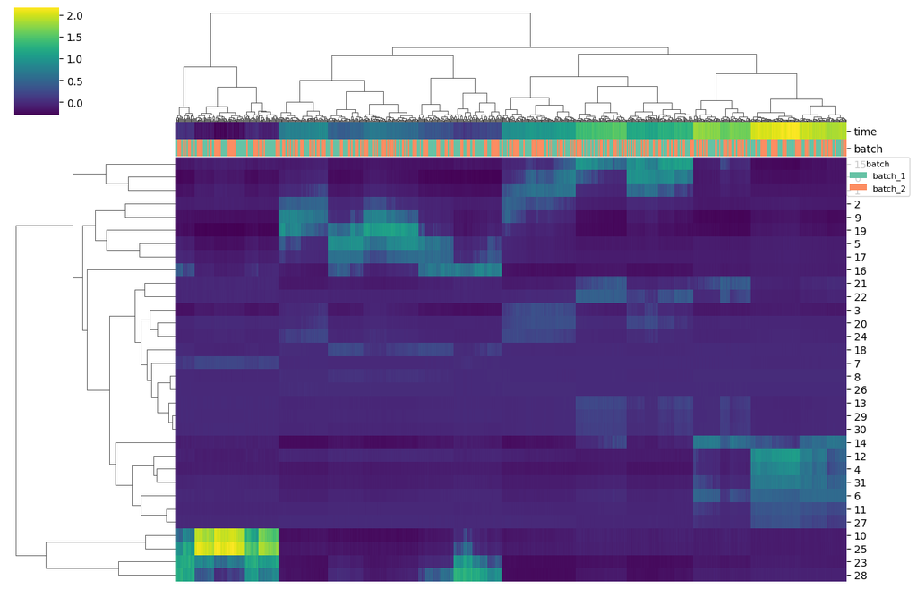

```python
sc.pp.neighbors(adata, n_neighbors=30, use_rep = 'Concord')
ccd.ul.run_umap(adata, source_key='Concord', result_key='Concord_UMAP_2D', n_components=2, n_neighbors=30, min_dist=0.5, metric='cosine', random_state=seed)

show_cols = [state_key, batch_key, leiden_key]
show_basis = 'Concord_UMAP_2D'
ccd.pl.plot_embedding(
    adata, show_basis, show_cols, figsize=(8,3), dpi=300, ncols=3, font_size=5, point_size=10, legend_loc='on data',
    #pal = {'cluster':'Set1', 'batch':'Set2', 'leiden':'tab20'},
    save_path=save_dir / f"{show_basis}_{file_suffix}.png"
)
```

sc.pp.neighbors(adata, n_neighbors=30, use_rep = 'Concord') ccd.ul.run_umap(adata, source_key='Concord', result_key='Concord_UMAP_2D', n_components=2, n_neighbors=30, min_dist=0.5, metric='cosine', random_state=seed) show_cols = [state_key, batch_key, leiden_key] show_basis = 'Concord_UMAP_2D' ccd.pl.plot_embedding( adata, show_basis, show_cols, figsize=(8,3), dpi=300, ncols=3, font_size=5, point_size=10, legend_loc='on data', #pal = {'cluster':'Set1', 'batch':'Set2', 'leiden':'tab20'}, save_path=save_dir / f"{show_basis}_{file_suffix}.png" )

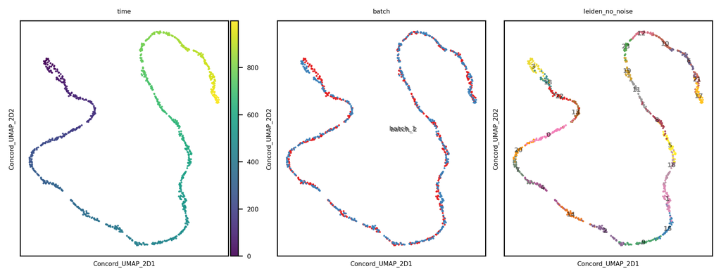

```python
adata.write_h5ad(data_dir / f"adata_{file_suffix}.h5ad")
adata_state.write_h5ad(data_dir / f"adata_state_{file_suffix}.h5ad")
```

adata.write_h5ad(data_dir / f"adata_{file_suffix}.h5ad") adata_state.write_h5ad(data_dir / f"adata_state_{file_suffix}.h5ad")